```r
library(ggplot2)
library(tseries)
library(forecast)
```

Análise de forma exploratório o banco de dados das médias de temperaturas globais mensais.

1. Decompor a série em seus componentes: tendência, sazonalidade e resíduos (componente aleatório). Elaborar gráfico com esses componentes. Você acredita que o efeito sazonal seja substancial? Compare o desvio padrão da série origninal com a série dessazonalizada. Elabore um gráfico com a tendência e a sazonalidade estimada.
2. Elabore um correlograma dos resíduos (componente aleatório). Comente o correlograma fazendo referências as correlações mais aparentes.

Abrindo dados

```r
www <- "https://raw.githubusercontent.com/prabeshdhakal/Introductory-Time-Series-with-R-Datasets/master/global.dat"
global <- scan(www)
```

Transformando os dados em ts:

```r
global.ts <- ts(global, st = c(1856, 1), end = c(2005, 12), fr = 12)
summary(global.ts) # sumário estatístico
```

```
##    Min. 1st Qu.  Median    Mean 3rd Qu.    Max.
## -1.0320 -0.3220 -0.1530 -0.1383  0.0280  0.8240
```

Embora o exercício esteja focado na decomposição, faz sentido observar um primeiro gráfico com a série temporal inteira.

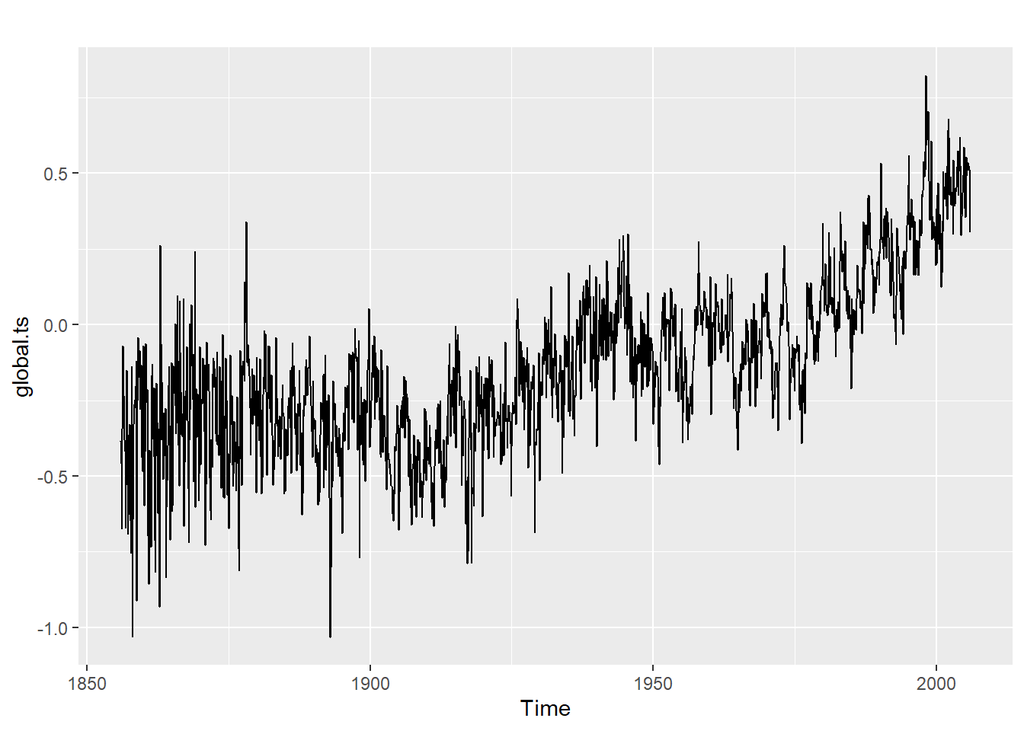

```r
autoplot(global.ts)
```

A série mostra um padrão claro de aumento da temperatura média global, afastando a hipótese de estacionariedade discutida em sala de aula. Os boxplots podem ajudar a investigar melhor a sazonalidade.

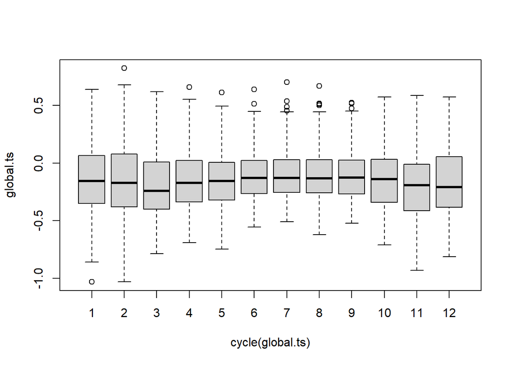

```r
boxplot(global.ts ~ cycle(global.ts))
```

Em relação as medidas de posição (mediana e quartis) não parece haver um efeito sazonal forte. A variabilidade das médias aumenta no início e no final dos anos, mas as aterações das medianas são de menor importância. Como trata-se de médias globais, temperaturas baixas são compensadas por altas, e quando tem-se inverno no hemisfério sul, tem-se verão no hemisfério norte.

Vamos, como proposto no exercício, decompor a série em seus componentes. Vamos adotar um modelo aditivo simples.

```r
global.decom <- decompose(global.ts, "additive")
```

Gráfico 4 - Decomposição

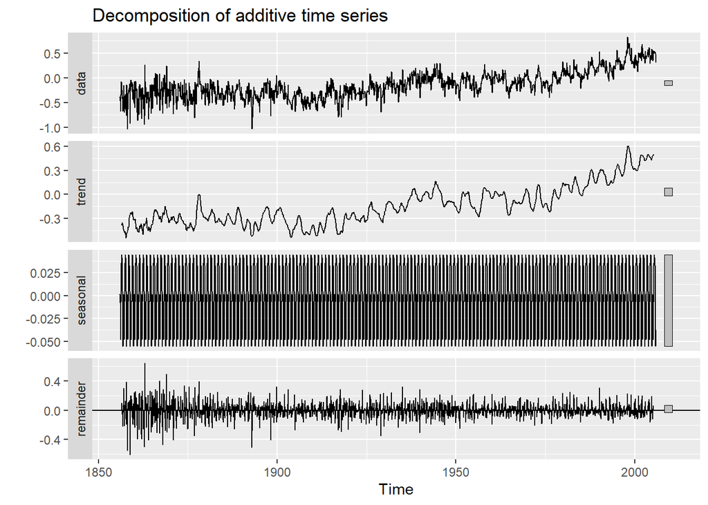

```r
autoplot(global.decom)
```

Um jeito de verificar se a sazonalidade é uma parte relevante da série temporal é observar se o desvio padrão cai consideravelmente na série dessazonalizada. Como proposto no exercício, vamos averiguar a importânica da sazonalidade por meio deste artifício:

```r
sd(global.ts[7:1794] - global.decom$trend[7:1794]) # Desvio Padrão seríe original
```

```
## [1] 0.1151801
```

O desvio padrão da série sem a tendência é 0.11.

```r
sd(global.decom$random[7:1794]) # Desvio padrão seríe dessazonalizada
```

```
## [1] 0.1103558
```

Para a série dessazonalizada (sem tendência e sem sazolnalidade), não temos um ganho expressivo na redução do desvio padrão da série, isto é, o componente aleatório responde, relativamente, por uma parte significativa da variabilidade dos dados.

Por fim, vamos produzir um gráfico com o efeito sazonal e tendência da série de temperatura sobrepostos.

```r
trend <- global.decom$trend
seasonal <- global.decom$seasonal
```

Gráfico 5 - Tendência e efeito sazonal

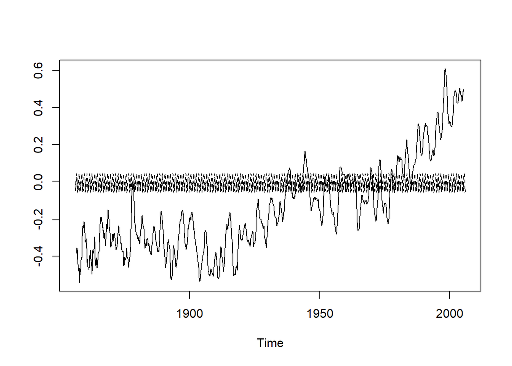

```r
ts.plot(cbind(trend, seasonal), lty = 1:2)
```

Nota-se, de fato, que a sazonalidade fica próxima de zero explicando pouco do comportamento da série.

A parte B) da questão pede um correlograma dos resíduos.

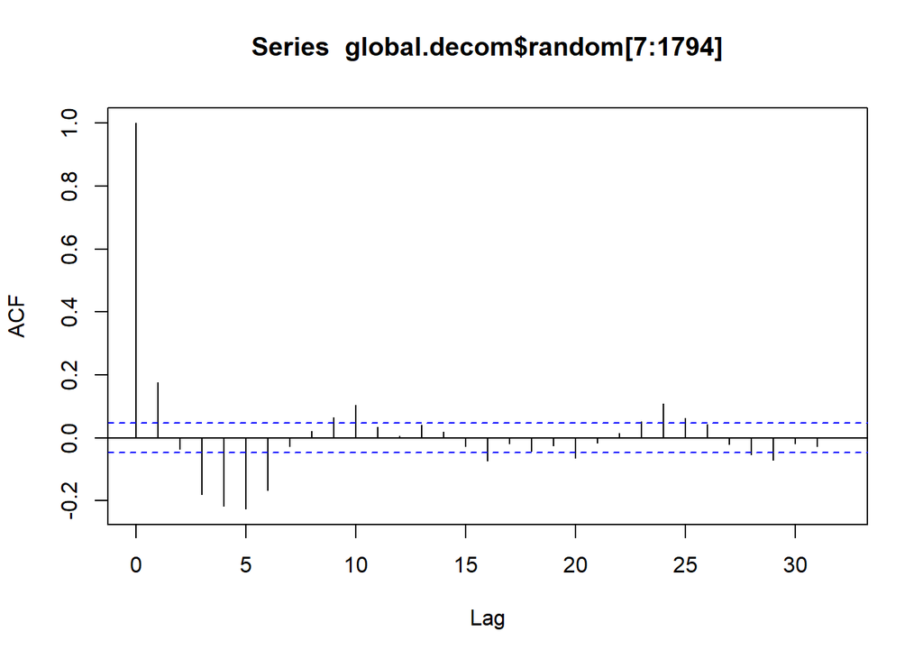

```r
acf(global.decom$random[7:1794]) # Em meses
```

O principal uso do correlograma é detectar autocorrelação em séries temporais depois de removermos a estimativa de tendência e sazonalidade. A Autocorrelação é a correlação entre a série temporal com valores defasados da própria série.

Temos no gráfico ACF que no LAG 0 é a correlação da série temporal com ela mesma, tendo assim uma correlação de 1. A linha azul tracejada indica a área de 95% do intervalo de confiança, logo tudo que esta dentro da área azul é estatisticamente próximo a 0 e tudo que esta fora é estatisticamente não 0.

Em vários pontos o correlograma apresenta autocorrelação significativa, indicando que os choques que levam ao aumento ou redução da temperatura média global tendem a “perdurar” ou estarem correlacionados no tempo.